# Manipulating XML and JSON data

Mahbubul Majumder, PhD  
Oct 16, 2014

### What is XML?

- It means EXtensible Markup Language
  - uses tags like HTML
  - but not HTML tags, instead user defined tags
- Unlike HTML, it is designed to describe data
- Data are self explained in XML format
  - software independent
  - hardware independent
  - very useful for transforming data in various platform
  - not too difficult to learn
- Data becomes verbose
  - for good reason though

### How HTML works with XML?

- XML separates data from HTML codes, so one can concentrate on
  - HTML style or CSS to effectively display data
  - XML data are stored in a different place and HTML can easily display
- Both works as a complement of each other
  - HTML helps display data
  - XML makes data easily transferable to any platform
  - XML also uses tags and attributes to describe data
- Some data structures can be very messy, but with XML we can control some
  - The usual table form just can't do it
- Scalable Vector Graphics (SVG) are written in XML
  - some of the figures you see on the web are not pictures
  - they are SVG and extremely scalable

### XML data tree

- Top node is **root** and bottom colored nodes are **leaves**
- Each node is an XML tag
- Each leaf is data value

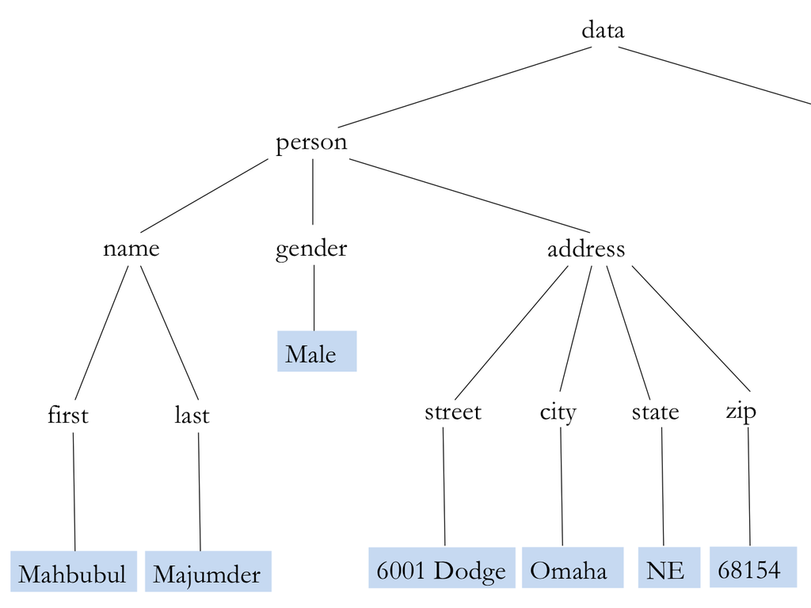

### XML data structure

- The tags are user defined, not HTML tags

```r
<?xml version="1.0"?>
<data>
 <person id='1'>
  <name>
    <first>Mahbubul</first>
    <last>Majumder</last>
  </name>
  <gender>Male</gender>
  <address>
    <street>6001 Dodge</street>
    <city>Omaha</city>
    <state>NE</state>
    <zip>68182</zip>
  </address>
 </person>
  ...
 <person id='n'>
  ...
 </person>
</data>
```

- What does this code mean?
  - first line indicates xml version
  - `<data>` is the root node
  - there are `n` child nodes with some hierarchy of subchild nodes
  - each child has an attribute id
  - `</data>` is end of the root node
- XML tree structure may have any number of hierarchy in child nodes.

```r
<root>
  <child>
    <subchild>
       .....
    </subchild>
  </child>
</root>
```

### Tips data in XML format

To view tips data visit [here](http://www.ggobi.org/book/data/tips.xml)  
Each triangle on the left will expand the view of the nodes  
We notice the tree structure

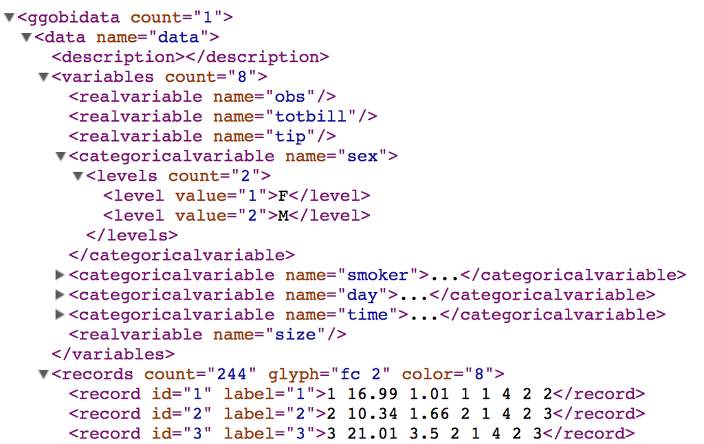

### Reading XML data in R

- `R` package XML provides functions to explore XML data

```r
# install.packages("XML")
library(XML)
```

- Very first step to work with XML file is to examine the file and view the structure
- Then parse the XML data to `R` object. Here we will use tips data from ggobi web site

```r
myUrl <- 'http://www.ggobi.org/book/data/tips.xml'
myDoc <- xmlParse(myUrl)
```

- Notice that there are two types of variables, real and categorical variables. First we will extract the real variable names.

```r
rvPath <- "//ggobidata/data/variables/realvariable"
rvList <- xpathApply(myDoc, rvPath, xmlAttrs)
rvNames <- as.vector(unlist(rvList))
rvNames
```

```
[1] "obs"     "totbill" "tip"     "size"
```

### Reading XML data in R cont..

- Now we will extract the categorical variable names.

```r
cvPath <- "//ggobidata/data/variables/categoricalvariable"
cvList <- xpathApply(myDoc, cvPath, xmlAttrs)
cvNames <- as.vector(unlist(cvList))
cvNames
```

```
[1] "sex"    "smoker" "day"    "time"
```

- Extracting data. Notice these are not attributes but values. Also split uses two spaces.

```r
datPath <- "//ggobidata/data/records/record"
datValue <- xpathApply(myDoc, datPath, xmlValue)
datValue <- strsplit(gsub('\\n','',datValue), split="  ")
head(datValue,2)
```

```
[[1]]
[1] "1"     "16.99" "1.01"  "1"     "1"     "4"     "2"     "2"

[[2]]
[1] "2"     "10.34" "1.66"  "2"     "1"     "4"     "2"     "3"
```

### Reading XML data in R cont..

- `datValue` is a list which contains each of the records of tips data. We need to convert it to a data frame. Also, notice how badly column names are arranged !

```r
tipDat <- do.call(rbind.data.frame, datValue)
names(tipDat) <- c(rvNames[-4],cvNames,rvNames[4])
head(tipDat)
```

```
  obs totbill  tip sex smoker day time size
1   1   16.99 1.01   1      1   4    2    2
2   2   10.34 1.66   2      1   4    2    3
3   3   21.01  3.5   2      1   4    2    3
4   4   23.68 3.31   2      1   4    2    2
5   5   24.59 3.61   1      1   4    2    4
6   6   25.29 4.71   2      1   4    2    4
```

- XML data structure could widely vary. The purpose of this presentation is to demonstrate how XML data could be explored. There could be smarter way of doing the same thing we did. But this gives us the insight of XML data structure.

### Getting column names of tips data

- Notice that the node, `variables`, is at depth 2 in the path and 2nd in the list at that depth. Also, notice how that can be accessed directly.

```r
r <- xmlRoot(myDoc)
varInfo <- r[[1]][[2]]
```

- `varInfo` contains values as below

```r
<variables count="8">
  <realvariable name="obs"/>
  <realvariable name="totbill"/>
  <realvariable name="tip"/>
  <categoricalvariable name="sex">
  ...
```

- We need to obtain all the name attributes which will be the column names

```r
as.vector(unlist(xmlApply(varInfo, xmlAttrs)))
```

```
[1] "obs"     "totbill" "tip"     "sex"     "smoker"  "day"     "time"
[8] "size"
```

### Levels of categorical variables

```r
cPath <- "//categoricalvariable/levels/level"
cLevels <- unlist(xpathApply(varInfo, cPath, xmlValue))
cLevels
```

```
 [1] "F"     "M"     "No"    "Yes"   "Thu"   "Fri"   "Sat"   "Sun"
 [9] "Day"   "Night"
```

```r
cPaths <- "//categoricalvariable/levels"
lvLength <- unlist(xpathApply(varInfo, cPaths, xmlSize))
lvLength
```

```
[1] 2 2 4 2
```

- This means first 2 levels are for first variable (sex), next 2 for 2nd variable(smoker), next 4 are for third variable(day) and final 2 levels are for the last categorical variable(time).

### Updating the levels of categorical variables

```r
k <- 0
for (i in seq(cvNames)){
  indx <-  1:lvLength[i] + k
  k <- k + lvLength[i]
  levels(tipDat[, cvNames[i]]) <- cLevels[indx]
  }

head(tipDat)
```

```
  obs totbill  tip sex smoker day  time size
1   1   16.99 1.01   F     No Sun Night    2
2   2   10.34 1.66   M     No Sun Night    3
3   3   21.01  3.5   M     No Sun Night    3
4   4   23.68 3.31   M     No Sun Night    2
5   5   24.59 3.61   F     No Sun Night    4
6   6   25.29 4.71   M     No Sun Night    4
```

- Homework  
  How can you do the same task without a loop?

### Other useful functions in XML package

- To get all the node sets under a node. By `*` we indicate whatever the node be

```r
getNodeSet(varInfo,'//*/levels')
```

- To access some children node of a node

```r
xmlChildren(varInfo)[1:4]
```

- What are these commands doing?

```r
r <- xmlRoot(myDoc)
## xmlName(r)
## xmlSize(r)
## xmlAttrs(r)
xmlValue(r[[1]][[2]])
```

```
[1] "FMNoYesThuFriSatSunDayNight"
```

- Please `? xmlToDataFrame` and `? xmlToList`

### Saving data into XML format?

```r
library(XML)
data <- head(women,4)

xmlDat <- xmlTree()
xmlDat$addTag("women", close=FALSE)
for (i in 1:nrow(data)) {
    xmlDat$addTag("vital", close=FALSE)
    for (j in names(data)) {
        xmlDat$addTag(j, data[i, j])
    }
    xmlDat$closeTag()
}
xmlDat$closeTag()
```

- To view the data we use cat command

```r
myXML <- cat(saveXML(xmlDat))
```

```
<?xml version="1.0"?>

<women>
  <vital>
    <height>58</height>
    <weight>115</weight>
  </vital>
  <vital>
    <height>59</height>
    <weight>117</weight>
  </vital>
  <vital>
    <height>60</height>
    <weight>120</weight>
  </vital>
  <vital>
    <height>61</height>
    <weight>123</weight>
  </vital>
</women>
```

### What is JSON?

- It stands for `J`ava`S`cript `O`bject `N`otation
  - main goal is to store and access data for the web
  - can be an alternative to XML
  - much easier to understand
  - very flexible to work with JavaScript
  - it is also language independent and self describing data format
- Differences with XML
  - it does not use tags
  - simpler than XML and easier to handle

### JSON data notation

```r
head(women)
```

```
  height weight
1     58    115
2     59    117
3     60    120
4     61    123
5     62    126
6     63    129
```

- JSON format could be

```r
{"women":[
    {"height":"58", "weight":"115"},
    {"height":"59", "height":"117"},
    {"height":"60", "height":"120"},
    {"height":"61", "weight":"123"},
    {"height":"62", "height":"126"},
    {"height":"63", "height":"129"}
]}
```

### Displaying JSON data using JavaScript

```r
<html>
<body>

<h2>Display JSON data</h2>

<p id="p1"></p>

<script>
var myData = '{"name":"Mahbubul Majumder","dept":"Dept. of Mathematics","phone":"402 5542734"}'

var obj = JSON.parse(myData);

document.getElementById("p1").
  innerHTML = obj.name + "<br>" +
  obj.dept + "<br>" +
  obj.phone;
</script>

</body>
</html>
```

## Display JSON data

### Getting JSON data into R

- The package `rjson` is created for this

```r
# install.packages("rjson")
library(rjson)
```

```r
jData <- toJSON(head(women))
jData
```

```
[1] "{\"height\":[58,59,60,61,62,63],\"weight\":[115,117,120,123,126,129]}"
```

```r
fromJSON(jData)
```

```
$height
[1] 58 59 60 61 62 63

$weight
[1] 115 117 120 123 126 129
```

### Reading assignment and references

- XML package information  
  http://www.omegahat.org/RSXML/shortIntro.pdf
- A nice discussion on How to get XML data into R  
  http://stackoverflow.com/questions/21790059/reading-xml-data-in-r
- To learn more about XML and how it works with examples please visit  
  http://www.w3schools.com/xml/default.asp
- To learn about JSON and practice online please visit  
  http://www.w3schools.com/json/